# 1. Daniel Bernoulli

## 2.3

**Use the posterior draws from b) to compute a 95% equal tail credible interval for G. A 95% equal tail credible interval (a, b) cuts off 2.5% percent of the posterior probability mass to the left of a, and 2.5% to the right of b.**

To obtain the 95%-CI we use the quantile()-method in R.

```r
ci <- quantile(ginis, probs = c(0.025, 0.975))
```

## 2.4

**Use the posterior draws from b) to compute a 95% Highest Posterior Density Interval (HPDI) for G. Compare the two intervals in (c) and (d). [Hint: Use the hdi() function from the bayestestR package.]**

```r
hpdi <- hdi(ginis, ci = 0.95)
cat("CI: ", ci)
```

```
## CI:  0.07219878 0.2196573
```

```r
print(hpdi)
```

```
## 95% HDI: [0.07, 0.20]
```

# 3.

## 3.1

$$L(\lambda; y) = \prod^n_{i=1}
\frac{\lambda^{k_i}e^{-\lambda}}{k_i!}=\frac{e^{-n\lambda}\cdot\lambda^{\sum^n_{i=1}k_i}}{\prod^n_{i=1}k_i!}\propto
e^{-n\lambda}\cdot\lambda^{\sum^n_{i=1}k_i}$$

$$p(\lambda|y,\sigma) \propto p(y|\lambda) \cdot p(\lambda|\sigma)$$

$$p(y|\lambda) = e^{-7\lambda}\cdot\lambda^{24}$$

$$p(\lambda|\sigma) \propto e^{\frac{-\lambda^2}{50}\cdot\lambda^{24}}$$

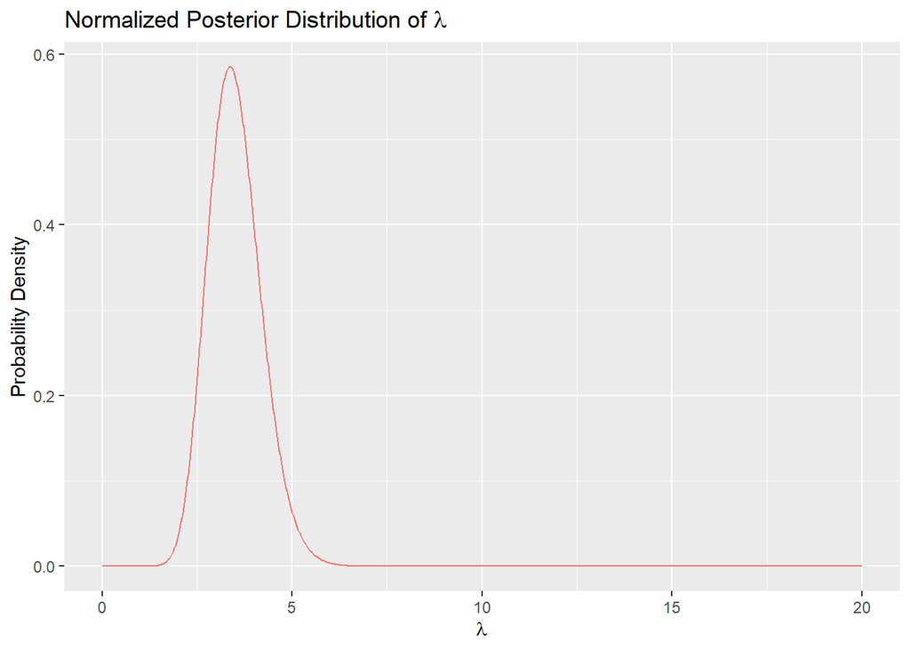

```r
lambda_grid <- seq(0, 20, length.out = 1000)
unnorm_posterior <- lambda_grid^24 * exp(-7 * lambda_grid - lambda_grid^2 / 50)
posterior <- unnorm_posterior / sum(unnorm_posterior * diff(lambda_grid)[1])

p <- ggplot() +
  aes(x=lambda_grid, y=posterior, col = "red") +
  geom_line() +
  ggtitle(expression(paste("Normalized Posterior Distribution of ", lambda))) +
  xlab(expression(lambda)) +
  ylab("Probability Density") +
  theme(legend.position="none")
print(p)
```

## 3.2

```r
mode <- lambda_grid[which.max(posterior)]
```